# Counterfactual Analysis

Mathew Kiang

8/29/2019

## Introduction

The analysis in our paper is entirely descriptive. However, to contextualize the opioid epidemic, we could imagine a counterfactual world in which the Black population experienced the same opioid-related mortality rate as the White population. What would this look like? How many more deaths would there be?

There are at least a couple ways to do this, but the simplest and most transparent way is to (1) apply the age-specific opioid-related mortality rates of the White population to the observed Black population for each year, and then (2) compare this *counterfactual* number of deaths to the observed number of deaths to get the number of “excess deaths” each year.

## Analysis

### Import the data

We’ll begin by loading up necessary packages and importing the data. Note that the data in [the paper](https://journals.lww.com/epidem/Fulltext/2018/09000/Trends_in_Black_and_White_Opioid_Mortality_in_the.16.aspx) only go up to 2015 so we use the data file from [an updated analysis](https://htmlpreview.github.io/?https://github.com/mkiang/opioid_trends/blob/master/rmds/add_analyses/add_2017_data.html) to get 2017 data.

```r
library(tidyverse)
library(here)
library(DT)

## Get from the 2017 branch that has updated data
age_spec <-
  readr::read_csv(
    paste0(
      "https://raw.githubusercontent.com/mkiang",
      "/opioid_trends/with-2017-data/data/",
      "age_specific_rates.csv"
    )
  )

## We're doing a black to white comparison so we don't need total population
age_spec <- age_spec %>%
    dplyr::filter(race != "total") %>%
    dplyr::arrange(race, year, age)
```

### Create an observed dataframe

We have age-specific mortality rates, but we want the actual number of deaths so we apply the rates back to the population. Note that the rate is per 100,000 and we `round()` off the error.

```r
observed_df <- age_spec %>%
    dplyr::filter(race == "black") %>%
    dplyr::transmute(
        year = year,
        age = age,
        age_cat = age_cat,
        pop_black = pop,
        obs_opioid_deaths = round(opioid_rate * pop_black / 100000),
        obs_drug_deaths = round(drug_rate * pop_black / 100000),
        obs_nonopioid_deaths = round(nonopioid_rate * pop_black / 100000),
        obs_opium_deaths = round(opium_rate * pop_black / 100000),
        obs_heroin_deaths = round(heroin_rate * pop_black / 100000),
        obs_natural_deaths = round(natural_rate * pop_black / 100000),
        obs_methadone_deaths = round(methadone_rate * pop_black / 100000),
        obs_synth_deaths = round(synth_rate * pop_black / 100000)
    )
```

Now, let’s collapse this across ages to get the total numnber of Black opioid-related deaths per year.

```r
observed_df <- observed_df %>%
    dplyr::group_by(year) %>%
    dplyr::select(year, dplyr::starts_with("obs")) %>%
    dplyr::summarize_all(sum)

## Reshape it to long
observed_df <- observed_df %>%
    tidyr::gather(death_type, observed, dplyr::starts_with("obs")) %>%
    dplyr::mutate(death_type = gsub("obs_|_deaths", "", death_type))
```

```r
DT::datatable(
  observed_df,
  rownames = FALSE,
  colnames = c("Year", "Opioid type", "Observed Deaths")
)
```

| Year | Opioid type | Observed Deaths |
| --- | --- | --- |
| 1979 | opioid | 160 |
| 1980 | opioid | 178 |
| 1981 | opioid | 179 |
| 1982 | opioid | 248 |
| 1983 | opioid | 213 |
| 1984 | opioid | 248 |
| 1985 | opioid | 284 |
| 1986 | opioid | 329 |
| 1987 | opioid | 320 |
| 1988 | opioid | 465 |

[output cut: 302 more lines]

### Create a counterfactual dataframe

We create a counterfactual dataframe by taking the age-specific population counts for Black Americans and applying the White age-specific opioid-related mortality rates.

```r
## Get Black population by year/age
black_pop <- age_spec %>%
    dplyr::filter(race == "black") %>%
    dplyr::select(year, age, age_cat, pop_black = pop)

## Now get the White rates and join with Black population
counter_df <- age_spec %>%
    dplyr::filter(race == "white") %>%
    dplyr::left_join(black_pop,
              by = c("year", "age", "age_cat")) %>%
    dplyr::select(year, age, age_cat, race, pop, pop_black, dplyr::everything())

## Calculate the Black deaths that would have occurred with White rate
counter_df <- counter_df %>%
    dplyr::transmute(
        year = year,
        age = age,
        age_cat = age_cat,
        pop_black = pop_black,
        cf_opioid_deaths = opioid_rate * pop_black / 100000,
        cf_drug_deaths = drug_rate * pop_black / 100000,
        cf_nonopioid_deaths = nonopioid_rate * pop_black / 100000,
        cf_opium_deaths = opium_rate * pop_black / 100000,
        cf_heroin_deaths = heroin_rate * pop_black / 100000,
        cf_natural_deaths = natural_rate * pop_black / 100000,
        cf_methadone_deaths = methadone_rate * pop_black / 100000,
        cf_synth_deaths = synth_rate * pop_black / 100000
    )
```

Let’s collapse ages to get the total number of counterfactual deaths per year.

```r
counter_df <- counter_df %>%
    dplyr::group_by(year) %>%
    dplyr::select(year, dplyr::starts_with("cf")) %>%
    dplyr::summarize_all(sum)

## Reshape to long
counter_df <- counter_df %>%
    tidyr::gather(death_type, counterfactual, dplyr::starts_with("cf")) %>%
    dplyr::mutate(death_type = gsub("cf_|_deaths", "", death_type))
```

```r
DT::datatable(
  counter_df,
  rownames = FALSE,
  colnames = c("Year", "Opioid type", "Counterfactual Deaths")
)
```

| Year | Opioid type | Counterfactual Deaths |
| --- | --- | --- |
| 1979 | opioid | 114.463311989381 |
| 1980 | opioid | 104.718314663084 |
| 1981 | opioid | 116.234072732142 |
| 1982 | opioid | 147.430508106953 |
| 1983 | opioid | 145.944745073873 |
| 1984 | opioid | 161.300614104607 |
| 1985 | opioid | 206.096584697614 |
| 1986 | opioid | 232.099293999792 |
| 1987 | opioid | 188.001021250303 |
| 1988 | opioid | 234.667158522441 |

[output cut: 302 more lines]

### Calculate the “excess deaths”

We want a dataframe that has the number of counterfactual deaths and the number of observed deaths for every year/drug type combination:

```r
excess_df <- counter_df %>%
    dplyr::left_join(
        observed_df,
        by = c("year", "death_type")
    ) %>%
    dplyr::mutate(excess = round(counterfactual - observed)) %>%
    dplyr::group_by(death_type) %>%
    dplyr::mutate(cumulative_excess = cumsum(excess)) %>%
    dplyr::ungroup()
```

Note that we cannot have “fractional deaths” so we round the excess results.

```r
DT::datatable(
  excess_df,
  rownames = FALSE,
  colnames = c(
    "Year",
    "Opioid type",
    "Counterfactual Deaths",
    "Observed Deaths",
    "Excess Deaths",
    "Cumulative Excess Deaths"
  )
)
```

| Year | Opioid type | Counterfactual Deaths | Observed Deaths | Excess Deaths | Cumulative Excess Deaths |
| --- | --- | --- | --- | --- | --- |
| 1979 | opioid | 114.463311989381 | 160 | -46 | -46 |
| 1980 | opioid | 104.718314663084 | 178 | -73 | -119 |
| 1981 | opioid | 116.234072732142 | 179 | -63 | -182 |
| 1982 | opioid | 147.430508106953 | 248 | -101 | -283 |
| 1983 | opioid | 145.944745073873 | 213 | -67 | -350 |
| 1984 | opioid | 161.300614104607 | 248 | -87 | -437 |
| 1985 | opioid | 206.096584697614 | 284 | -78 | -515 |
| 1986 | opioid | 232.099293999792 | 329 | -97 | -612 |
| 1987 | opioid | 188.001021250303 | 320 | -132 | -744 |
| 1988 | opioid | 234.667158522441 | 465 | -230 | -974 |

[output cut: 302 more lines]

## Plot the number of excess deaths, by type, 1979 to 2017 (ICD-9 categories)

Note, in 1999, the CDC switched from ICD-9 to ICD-10. Therefore, for 1978 to 1998, opioid categories only consisted of all opioids, heroin, opium, or methatdone. We plot the excess deaths here:

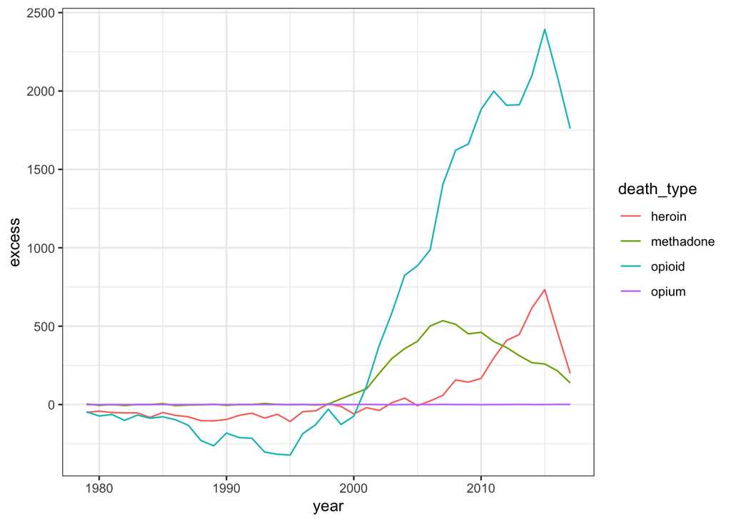

```r
ggplot2::ggplot(
  excess_df %>%
    dplyr::filter(death_type %in% c("opioid", "heroin", "opium", "methadone")),
  ggplot2::aes(x = year, y = excess, color = death_type)
) +
  ggplot2::geom_line() +
  ggplot2::theme_bw()
```

## Plot the number of excess deaths, by type, 1999 to 2017 (ICD-10 categories)

The ICD-10 data (1999 to 2017) have finer opioid categories. Note the changing y-axis scale:

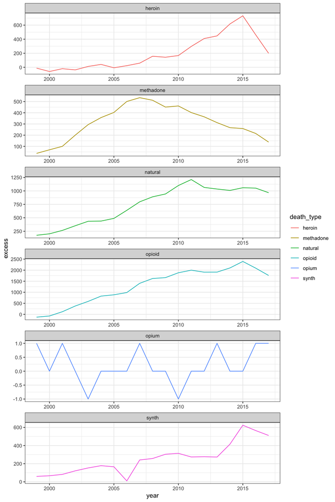

```r
ggplot2::ggplot(
  excess_df %>%
    dplyr::filter(year > 1998) %>%
    dplyr::filter(
      death_type %in% c("opioid", "heroin", "opium", "methadone", "natural", "synth")
    ),
  ggplot2::aes(x = year, y = excess, color = death_type)
) +
  ggplot2::geom_line() +
  ggplot2::facet_wrap(~ death_type,
                      ncol = 1,
                      scales = "free") +
  ggplot2::theme_bw()
```

## Plot the *cumulative* number of excess deaths, by type, 1979 to 2017 (ICD-9 categories)

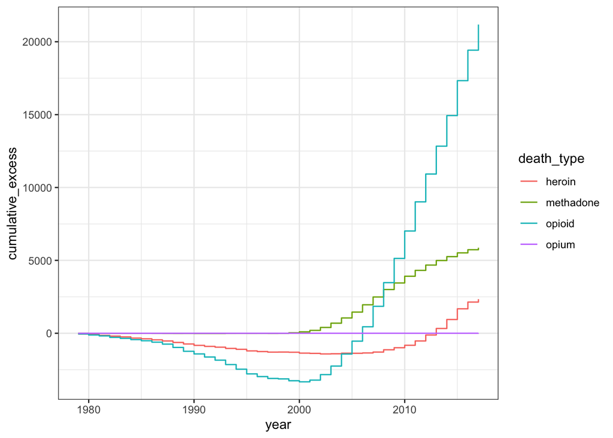

```r
ggplot2::ggplot(
  excess_df %>%
    dplyr::filter(death_type %in% c("opioid", "heroin", "opium", "methadone")),
  ggplot2::aes(x = year, y = cumulative_excess, color = death_type)
) +
  ggplot2::geom_step() +
  ggplot2::theme_bw()
```

## Plot the *cumulative* number of excess deaths, by type, 1999 to 2017 (ICD-10 categories)

Again, note the changing y-axis scale.

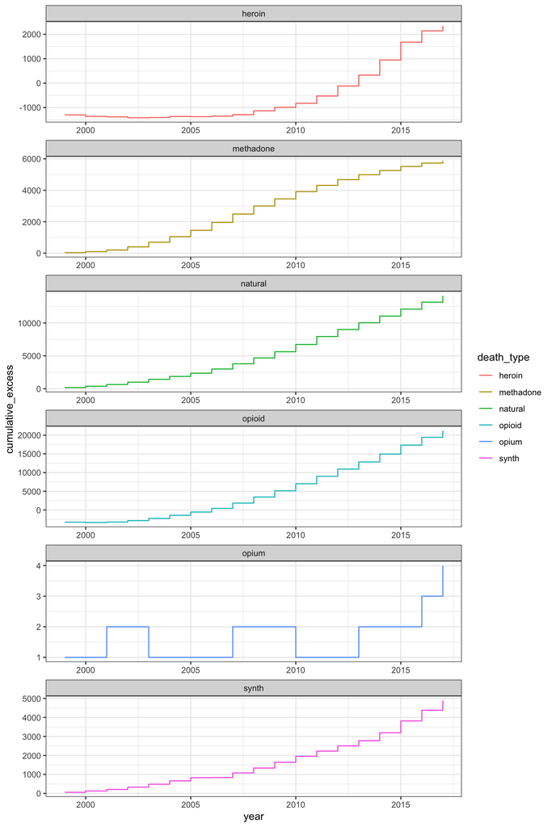

```r
ggplot2::ggplot(
  excess_df %>%
    dplyr::filter(year > 1998) %>%
    dplyr::filter(
      death_type %in% c("opioid", "heroin", "opium", "methadone", "natural", "synth")
    ),
  ggplot2::aes(x = year, y = cumulative_excess, color = death_type)
) +
  ggplot2::geom_step() +
  ggplot2::facet_wrap(~ death_type,
                      ncol = 1,
                      scales = "free") +
  ggplot2::theme_bw()
```

## Conclusion

Under the assumptions of our model, between 1979 and 2017, there would have been:

- 21,181 more opioid-related deaths in the Black population.
- 2,339 more heroin-related deaths in the Black population.
- 5,869 more methadone-related deaths in the Black population.

Between 1999 and 2017, when the death certificates had more opioid types, there would have been:

- 14,124 more prescription opioid related deaths in the Black population.
- 4,892 more synthetic opioid related deaths in the Black population.

From 1979 to about 2000, the Black opioid-related mortality rate was higher than the the White opioid-related mortality rate. Under the same assumptions of our model, there would have been 3,332 fewer opioid-related deaths in the Black population from 1979 to 2000.

### Limitations

This is a straightforward analysis with strong assumptions. This isn’t meant to be comprehensive or sophisticated — rather it is meant to be transparent. These results reflect an impossible world where the opioid-related mortality rate in the Black population is identical to the White population, where the public health and medical response to the epidemic would remain the same, and where the supply, demand, and production of the illicit drug market would have been the same.

On top of this, all limitations in [our paper](https://journals.lww.com/epidem/Fulltext/2018/09000/Trends_in_Black_and_White_Opioid_Mortality_in_the.16.aspx) regarding the data still hold. Opioid-related deaths have undoubtedly increased over this period, but so has our detection and testing of them — we cannot disentangle how much of the increase is due to increasing prevalence of testing over time and how much is due to increasing deaths. Likewise, there is substantial geographic variation in the quality of post-mortem testing.

### Save `csv`

The data can be found online [in the Github repo.](https://github.com/mkiang/opioid_trends/blob/master/rmds/add_analyses/counterfactual_analysis_excess_deaths.csv)

```r
readr::write_csv(excess_df, "./counterfactual_analysis_excess_deaths.csv")
```